# Housing Prices - Lasso, xgboost

Prabha

9/9/2018

Inspired by this kernel https://www.kaggle.com/erikbruin/house-prices-lasso-xgboost-and-a-detailed-eda

```r
library(tidyverse)
library(tidyimpute)
```

```r
library(corrplot)
library(caret)
library(xgboost)
```

Below , i am reading the train / test csv as dataframes in R

```r
train=read_csv("datasets/train.csv")
test=read_csv("datasets/test.csv")
```

Getting the dimensions of the dataset , and looks like difference between train and test is “SalePrice” as expected

```r
dim(train)
```

```
## [1] 1460   81
```

```r
dim(test)
```

```
## [1] 1459   80
```

```r
setdiff(colnames(train),colnames(test))
```

```
## [1] "SalePrice"
```

Getting rid of IDs from the dataframe , but we need to keep test_ids fro final submission to kaggle

```r
test_id=test$Id
test$Id=NULL
train$Id=NULL
```

combining both train and test for cleaning and feature engineering

```r
test$SalePrice=NA
all=rbind(train,test)
dim(all)
```

```
## [1] 2919   80
```

Exploring teh important variables

1. Response Variable - SalePrice

the sale price are right skewed. We need to handle this scenario before modeling.

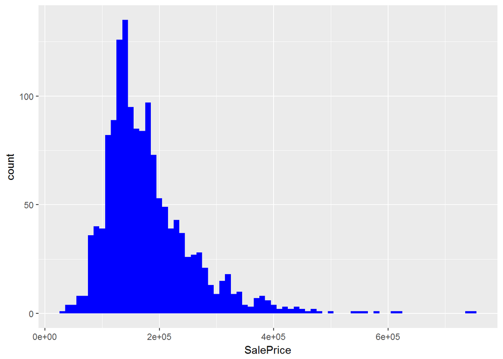

```r
all %>% drop_na(SalePrice) %>% ggplot(aes(x=SalePrice))+geom_histogram(fill="blue",binwidth=10000)
```

```r
summary(all$SalePrice)
```

```
##    Min. 1st Qu.  Median    Mean 3rd Qu.    Max.    NA's
##   34900  130000  163000  180900  214000  755000    1459
```

Find the most important numeric predictors

first focus on numeric predictors, there are 37 numeric columns including SalePrice

```r
all %>% select_if(is.numeric) %>% dim()
```

```
## [1] 2919   37
```

```r
all_numVar=all %>% select_if(is.numeric)
cor_numVar=cor(all_numVar,use="pairwise.complete.obs")
```

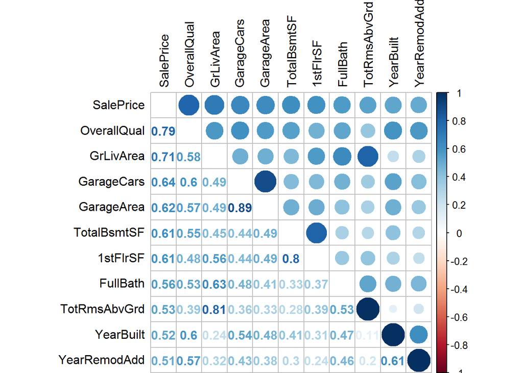

```r
cor_sorted=as.matrix(sort(cor_numVar[,'SalePrice'],decreasing = TRUE))
high_corr=names(cor_sorted[cor_sorted>0.5,])
corr_numVar=cor_numVar[high_corr,high_corr]
corrplot.mixed(corr_numVar,tl.pos="lt",tl.col="black")
```

lets explore ‘overallqual’ variable, there is definitively positive influence on the SalePrice

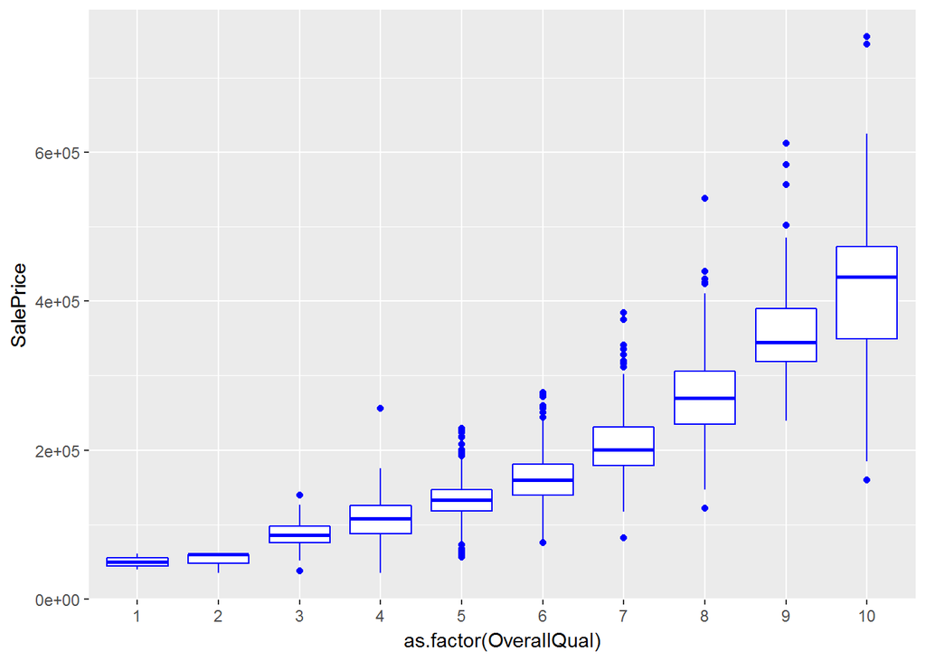

```r
all %>% drop_na(SalePrice) %>% ggplot(aes(x=as.factor(OverallQual),y=SalePrice))+geom_boxplot(col="blue")
```

Next ‘GrLvArea’ variable, there are two outliers with hign GrLivArea but low SalePrice

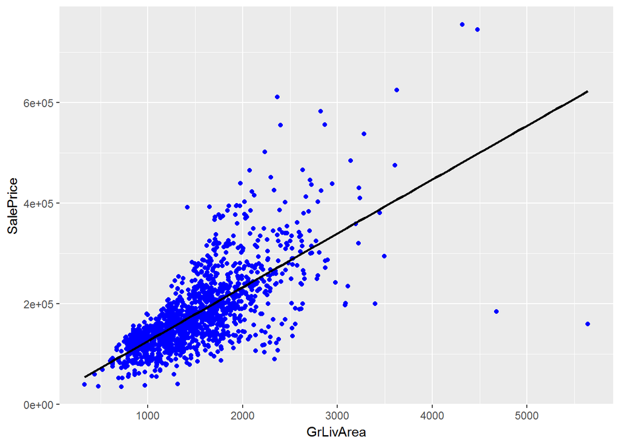

```r
all %>% drop_na(SalePrice) %>%ggplot(aes(x=GrLivArea,y=SalePrice))+geom_point(col='blue')+geom_smooth(method='lm',se=FALSE,col='black')
```

Handling missing data, label encoding & factorizing variables find out the variables containing missing values, we have to fix 34 predictors

```r
NA_col=names(which(colSums(is.na(all))>0))
sort(sort(colSums(is.na(all[,NA_col]))),decreasing = TRUE)
```

```
##       PoolQC  MiscFeature        Alley        Fence    SalePrice
##         2909         2814         2721         2348         1459
##  FireplaceQu  LotFrontage  GarageYrBlt GarageFinish   GarageQual
##         1420          486          159          159          159
##   GarageCond   GarageType     BsmtCond BsmtExposure     BsmtQual
##          159          157           82           82           81
## BsmtFinType2 BsmtFinType1   MasVnrType   MasVnrArea     MSZoning
##           80           79           24           23            4
##    Utilities BsmtFullBath BsmtHalfBath   Functional  Exterior1st
##            2            2            2            2            1
##  Exterior2nd   BsmtFinSF1   BsmtFinSF2    BsmtUnfSF  TotalBsmtSF
##            1            1            1            1            1
##   Electrical  KitchenQual   GarageCars   GarageArea     SaleType
##            1            1            1            1            1
```

```r
cat('There are ',length(NA_col),' columsn with missing values')
```

```
## There are  35  columsn with missing values
```

Imputing missing data

### Pool

The PoolQC is the variable with most NAs. PoolQC : Pool quality

Ex Excellent Gd Good TA Average/Typical Fa Fair NA No Pool

It is obvious most houses will not have pools . these values can be converted as ordinal

```r
all$PoolQC[is.na(all$PoolQC)]='None'
all$PoolQC=as.integer(recode(all$PoolQC,'None'=0,'po'=1,'Fa'=2,'TA'=3,'Gd'=4,'Ex'=5))
```

There are three instances where PoolQC is missing while PoolArea is greater than zero. Iam going to impoute based on overall quality

```r
all %>% filter(PoolArea>0 & PoolQC==0) %>% select(PoolArea,PoolQC,OverallQual)
```

```
## # A tibble: 3 x 3
##   PoolArea PoolQC OverallQual
##      <int>  <int>       <int>
## 1      368      0           4
## 2      444      0           6
## 3      561      0           3
```

```r
all[all$PoolArea==368 & all$OverallQual==4,]['PoolQC']=2
all[all$PoolArea==444 & all$OverallQual==6,]['PoolQC']=3
all[all$PoolArea==561 & all$OverallQual==3,]['PoolQC']=2
```

### Miscellaneous Feature

There are 2814 missing values in ’MiscFeature, As these values are nor ordinal i will convert into factors Gar2 2nd Garage (if not described in garage section) Othr Other Shed Shed (over 100 Sf) TenC Tennis Court NA None

```r
table(all$MiscFeature,exclude = NULL)
```

```
##
## Gar2 Othr Shed TenC <NA>
##    5    4   95    1 2814
```

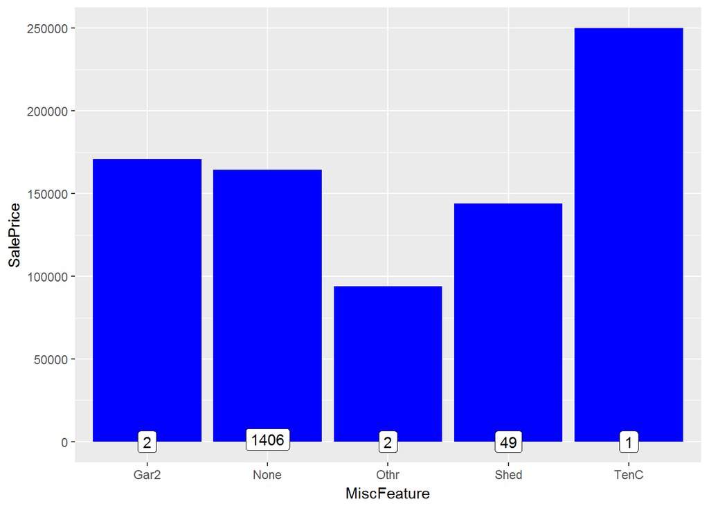

```r
all=all %>%  replace_na(list(MiscFeature="None"))
all$MiscFeature=as.factor(all$MiscFeature)
all %>% drop_na(SalePrice) %>% ggplot(aes(x=MiscFeature,y=SalePrice))+geom_bar(stat='summary',fun.y="median",fill='blue')+geom_label(stat="count",aes(label=..count..,y=..count..))
```

### Alley

Convert values to factors as it is not ordinal

```r
table(all$Alley,exclude = NULL)
```

```
##
## Grvl Pave <NA>
##  120   78 2721
```

Grvl Gravel Pave Paved NA no alley access

```r
all=all %>% replace_na(list(Alley="None"))
all$Alley=as.factor(all$Alley)
```

### Fence

Fence has 2348 missing values,

```r
table(all$Fence,exclude = NULL)
```

```
##
## GdPrv  GdWo MnPrv  MnWw  <NA>
##   118   112   329    12  2348
```

```r
all=all %>% replace_na(list(Fence="None"))
table(all$Fence,exclude=NULL)
```

```
##
## GdPrv  GdWo MnPrv  MnWw  None  <NA>
##   118   112   329    12  2348     0
```

```r
all %>% drop_na(SalePrice) %>% group_by(Fence) %>% summarise(median=median(SalePrice),mean=mean(SalePrice),count=n())
```

```
## # A tibble: 5 x 4
##   Fence median    mean count
##   <chr>  <dbl>   <dbl> <int>
## 1 GdPrv 167500 178927.    59
## 2 GdWo  138750 140379.    54
## 3 MnPrv 137450 148751.   157
## 4 MnWw  130000 134286.    11
## 5 None  173000 187597.  1179
```

at the first look Fence looks like an ordinal value but median value shown no fence house has higher median and mean prices , hence i will convert fence as factor

```r
all$Fence=as.factor(all$Fence)
```

### Fireplace varaibale

Fireplace has NAs . Number of fireplace does not have any NAs.looks like NA is for the house with zero fireplaces

```r
table(all$FireplaceQu,all$Fireplaces,exclude=NULL)
```

```
##
##           0    1    2    3    4 <NA>
##   Ex      0   37    5    1    0    0
##   Fa      0   63   10    1    0    0
##   Gd      0  627  112    5    0    0
##   Po      0   46    0    0    0    0
##   TA      0  495   92    4    1    0
##   <NA> 1420    0    0    0    0    0
```

```r
all=all %>% replace_na(list(FireplaceQu="None"))
all$FireplaceQu=as.integer(recode(all$FireplaceQu,'None'=0,'Po'=1,'Fa'=2,'TA'=3,'Gd'=4,'Ex'=5))
table(all$FireplaceQu)
```

```
##
##    0    1    2    3    4    5
## 1420   46   74  592  744   43
```

### Lot variables

LotFrontage : 486 NAs. reasonable is impute meadian value per neighborhood

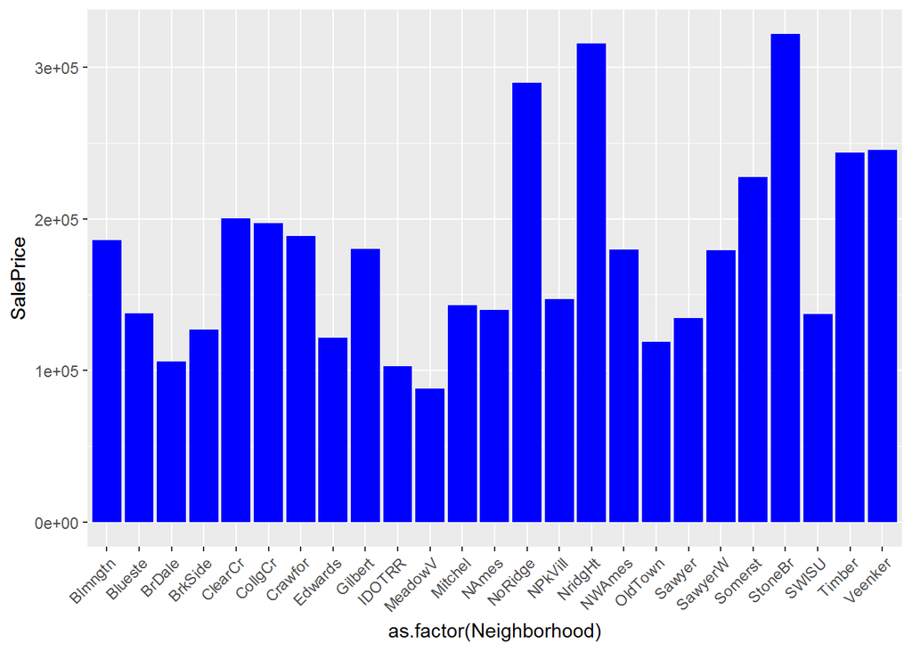

```r
all %>% drop_na(LotFrontage,SalePrice) %>% ggplot(aes(x=as.factor(Neighborhood),y=SalePrice))+geom_bar(stat="summary",fun.y="median",fill="blue") + theme(axis.text.x = element_text(angle=45,hjust=1))
```

```r
all=all %>% group_by(Neighborhood) %>% mutate(LotFrontage=ifelse(is.na(LotFrontage),median(LotFrontage,na.rm=T),LotFrontage))
```

LotShape :No NAs , values seems ordinal Reg Regular IR1 Slightly irregular IR2 Moderately Irregular IR3 Irregular

```r
all$LotShape=as.integer(recode(all$LotShape,'IR3'=0,'IR2'=1,'IR1'=2,'Reg'=3))
```

LotConfig : No NAs. The value seems ordinal but visualizing it tells that it may not be ordinal. hence making it factor

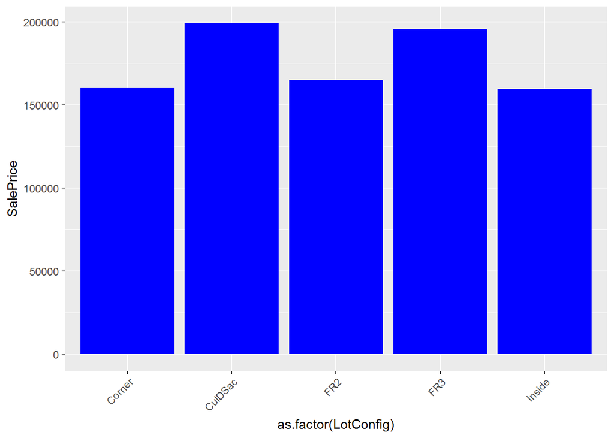

```r
all %>% drop_na(LotFrontage,SalePrice) %>%ggplot(aes(x=as.factor(LotConfig),y=SalePrice))+geom_bar(stat="summary",fun.y="median",fill="blue") +theme(axis.text.x = element_text(angle=45,hjust=1))
```

```r
all$LotConfig=as.factor(all$LotConfig)

table(all$LotConfig,exclude=NULL)
```

```
##
##  Corner CulDSac     FR2     FR3  Inside    <NA>
##     511     176      85      14    2133       0
```

### Garage Variables

There are 7 Garage varaiables ,

```r
garage_variables=grep("Garage*",colnames(all),value = TRUE)
colSums(is.na(all[,garage_variables]))
```

```
##   GarageType  GarageYrBlt GarageFinish   GarageCars   GarageArea
##          157          159          159            1            1
##   GarageQual   GarageCond
##          159          159
```

For GarageYrBlt i am going to replace with YearBuilt variable

```r
all$GarageYrBlt[is.na(all$GarageYrBlt)]=all$YearBuilt[is.na(all$GarageYrBlt)]
```

lets check 157/159 missing values are the same observations . looks missing values are from the same observation

```r
length(which(is.na(all$GarageType) & is.na(all$GarageFinish) & is.na(all$GarageQual) & is.na(all$GarageCond)))
```

```
## [1] 157
```

lets explore the two observations where GarageType has values. Observation 2127 does have seem have garage so lets imoute with common values

```r
all[which(!is.na(all$GarageType) & is.na(all$GarageFinish)),garage_variables]
```

```
## # A tibble: 2 x 7
##   GarageType GarageYrBlt GarageFinish GarageCars GarageArea GarageQual
##   <chr>            <int> <chr>             <int>      <int> <chr>
## 1 Detchd            1910 <NA>                  1        360 <NA>
## 2 Detchd            1923 <NA>                 NA         NA <NA>
## # ... with 1 more variable: GarageCond <chr>
```

```r
which(!is.na(all$GarageType) & is.na(all$GarageFinish))
```

```
## [1] 2127 2577
```

```r
all$GarageCond[2127]=names(sort(table(all$GarageCond),decreasing = TRUE)[1])
all$GarageQual[2127]=names(sort(table(all$GarageQual),decreasing = TRUE)[1])
all$GarageFinish[2127]=names(sort(table(all$GarageFinish),decreasing = TRUE)[1])
```